# Métodos y simulación estadística Actividad 2 - Caso Teorema del límite central: Ejercicio 3

David Aguilar y Christian Bermúdez.

10/03/2024

**Nota: Documento académico para la Maestría en ciencia de datos de la Universidad Javeriana de Cali**

Según lo mencionado en el material del curso, el Teorema Central del Límite establece que, dada una muestra suficientemente grande de una población con una media y varianza finitas, la distribución de las medias muestrales tiende a ser normal, independientemente de la forma de la distribución de la población. Con este ejercicio, se presenta una forma de darle aplicabilidad a este teorema mediante una simulación:

# 1 Punto A

Realice una simulación en la cual genere una población de n = 1000 (Lote), donde el porcentaje de individuos (supongamos plantas) enfermas sea del 50%.

Respuesta:

Se utiliza el comando rbinom para una distribución binomial con probabilidad de 50%, se hace solo una simulación para 1000 plantas.

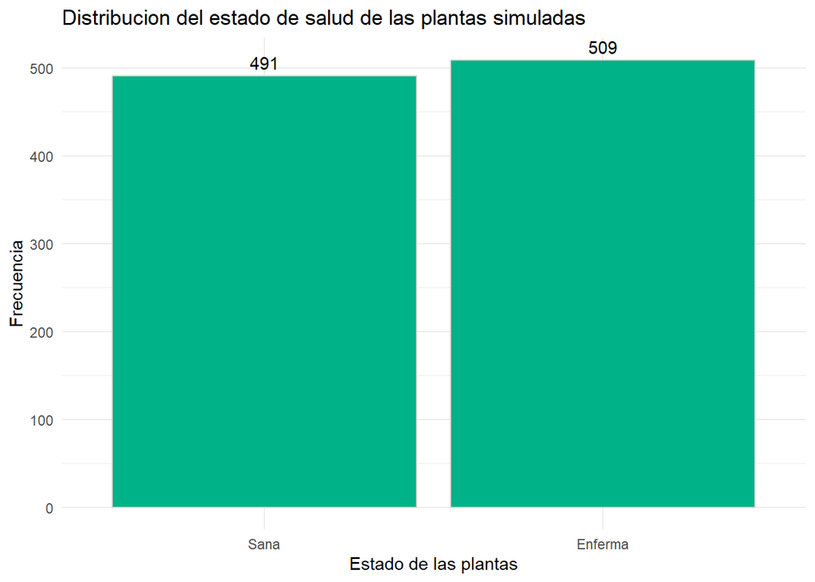

```r
# Primero definimos el tamaño de la población o lote
n = 1000

# Simulamos la población de plantas con un 50% de probabilidad de estar enfermas
X = rbinom(n, size = 1, prob = 0.5)


# graficamos la distribución usando la librería ggplot2
library(ggplot2)


# convertimos los datos en un data frame
graficopunto1 <- data.frame(Resultado_planta = factor(X, labels = c("Sana", "Enferma")))

# creamos el gráfico con ggplot
ggplot(graficopunto1, aes(x = Resultado_planta)) +
  geom_bar(fill = "#00B288", color = "#DCD5CB") +
  geom_text(stat = 'count',  aes(label = after_stat(count)), vjust = -0.5) +
  labs(title = "Distribucion del estado de salud de las plantas simuladas",
       x = "Estado de las plantas",
       y = "Frecuencia") +
  theme_minimal()
```

# 2 Punto B

Genere una función que permita:

- Obtener una muestra aleatoria de la población y
- Calcule el estimador de la proporción muestral $\hat{p}$ para un tamaño de muestra dado $n$

Respuesta:

El estimador es $\hat{p} = \frac{1}{n} \sum_{i=1}^{n} X_i$, donde $X_i$ es igual a 1 si es una planta enferma. Este estimador es igual al promedio de cada una de las distribuciones, porque se suma el total de los datos y se divide en el número total de datos.

A continuación, se muestra el cóigo de generación de la función y el resultado para una muestra aleatorio de tamaño $n$:

```r
# Definimos la función para calcular el estimador de la proporción de plantas enfermas
calcular_proporcion_enfermos <- function(n) {
  # Obtenemos una muestra aleatoria de la población, como lo hicimos en el literal anterior
  muestra <- rbinom(n, size = 1, prob = 0.5)

  # Calculamos la proporción de plantas enfermas en la muestra (dividimos la suma de enfermos por el total de la muestra)
  proporcion_enfermos <- sum(muestra) / n



  # cierre del código para garantizar que se retorna la proporción de plantas enfermas
  return(proporcion_enfermos)
}

# Ejemplo de uso. como el del caso anterior para un tamaño de muestra n = 1000
n = 1000
proporcion_enfermos <- calcular_proporcion_enfermos(n)
```

```r
    # Imprimimos la proporción de plantas enfermas
  print(proporcion_enfermos)
```

```
## [1] 0.52
```

# 3 Punto C

Repita el escenario anterior (b) n=500 veces y analice los resultados en cuanto al comportamiento de los 500 resultados del estimador ¿Qué tan simétricos o sesgados son los resultados obtenidos? y ¿qué se puede observar en cuanto a la variabilidad?. Realice en su informe un comentario sobre los resultados obtenidos.

Respuesta:

Se utiliza el comando sapply() para repetir lo realizado previamente con la función:

```r
# Aplicamos la función que creamos calcular_proporcion_enfermos(n) 500 veces como nos lo piden con sapply()
tamaños_muestra = rep(1000, 500) # Repite el tamaño de muestra n = 1000, 500 veces
proporciones_enfermos = sapply(tamaños_muestra, calcular_proporcion_enfermos)
```

Revisamos las estadisticas descriptivas de los 500 datos de proporciones (medias) que encontramos y vemos que el promedio del estimador es de 0.5 y su mediana también, lo que indica que el estimador tiende a la media que es que el 50% de las plantas enfermas.

```r
# Usamos la librería psych
library(psych)
# Usamos describe() para obtener las estadísticas descriptivas de proporciones_enfermos
describe(proporciones_enfermos)
```

|  | vars | n | mean | sd | median | trimmed | mad | min | max | range | skew | kurtosis | se |
| --- | --- | --- | --- | --- | --- | --- | --- | --- | --- | --- | --- | --- | --- |
| X1 | 1 | 500 | 0.500228 | 0.01551649 | 0.5 | 0.500185 | 0.0163086 | 0.46 | 0.553 | 0.093 | 0.03568112 | -0.2207838 | 0.0006939186 |

Prcedemos a ver en un histograma la distribución de los estimadores en la simulación realizada 500 veces e identificar cómo tiende a una distribución normal.

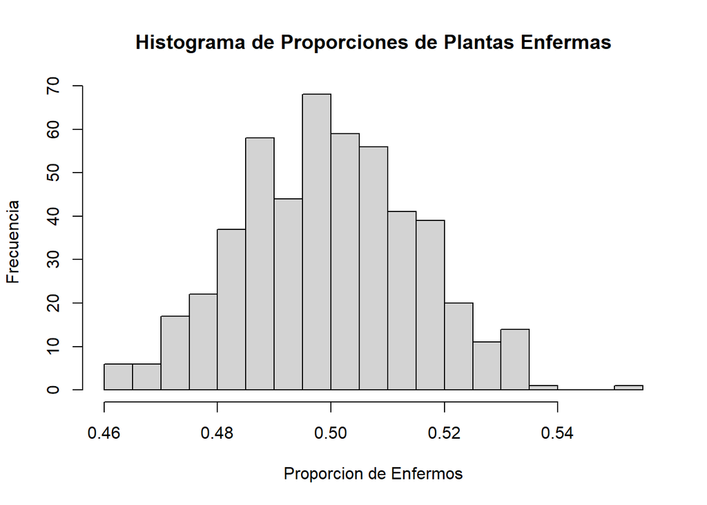

```r
# Creamos un histograma de las proporciones de plantas enfermas
hist(proporciones_enfermos, main = "Histograma de Proporciones de Plantas Enfermas", xlab = "Proporcion de Enfermos", ylab = "Frecuencia", breaks = 30)
```

Revisamos qué tanto se ajusta a la distribución normaly encontramos que las distribuciones de las medias tienden a uan normal.

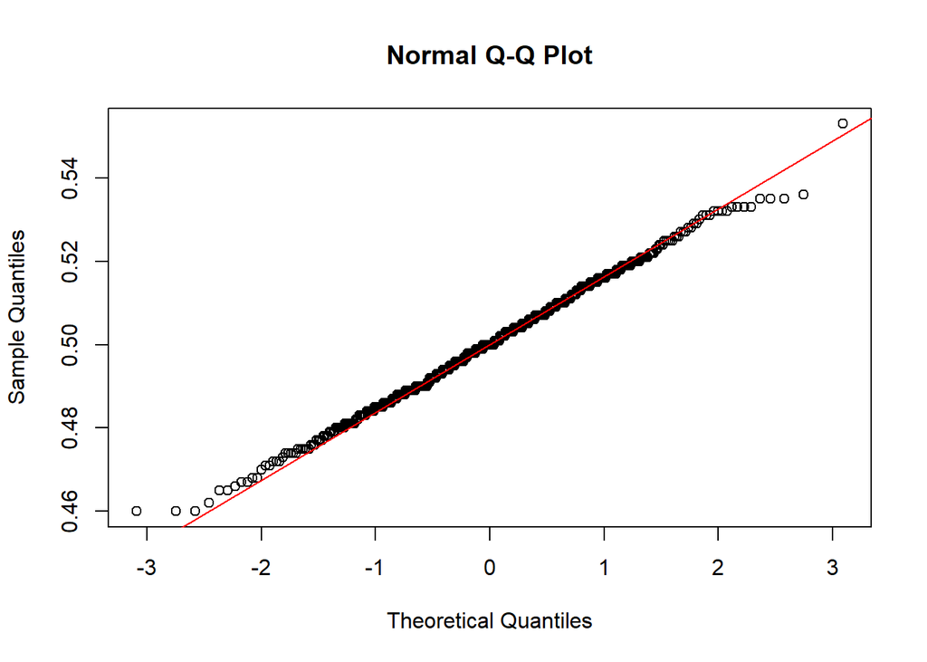

```r
# Generamos el gráfico QQ para las proporciones de plantas enfermas
qqnorm(proporciones_enfermos)
qqline(proporciones_enfermos, col="red")
```

Creamos un boxplot para ver la variabilidad de los datos y se identfica que los datos no se encuentran distribuidos hacia alguna cola específica y que no tiende haber sesgo en la estimación.

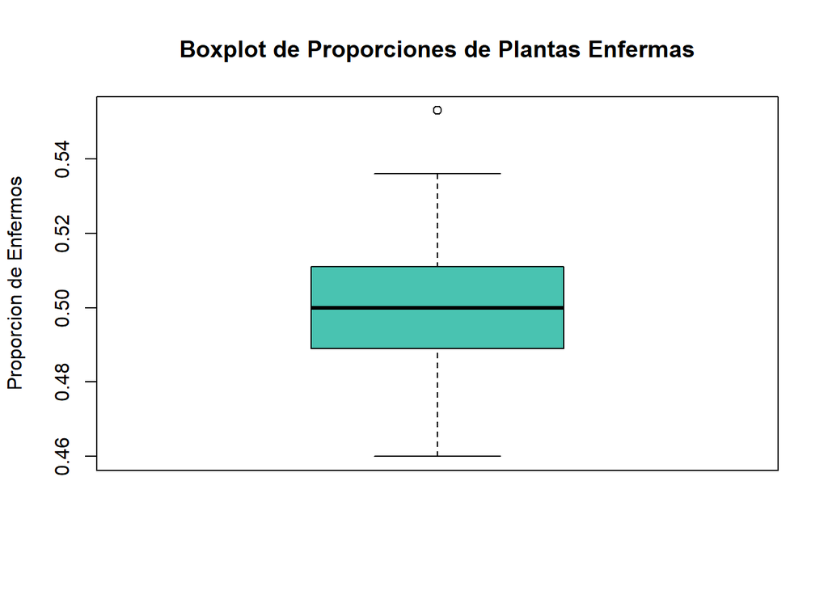

```r
# Creamos un boxplot de las proporciones de plantas enfermas
boxplot(proporciones_enfermos, main = "Boxplot de Proporciones de Plantas Enfermas", ylab = "Proporcion de Enfermos", horizontal = FALSE, col = "#49C3B1")
```

# 4 punto D

Repita los puntos b y c para tamaños de muestra n=5, 10 15, 20, 30, 50, 60, 100, 200, 500. Compare los resultados obtenidos para los diferentes tamaños de muestra en cuanto a la normalidad. Utilice pruebas de bondad y ajuste (shapiro wilks :shspiro.test()) y métodos gráficos (gráfico de normalidad: qqnorm()). Comente en su informe los resultados obtenidos.

Respuesta:

Revisamos las distribuciones de la media (el estimador) para cada número de n y vemos cómo se aproxima a la distribución normal.

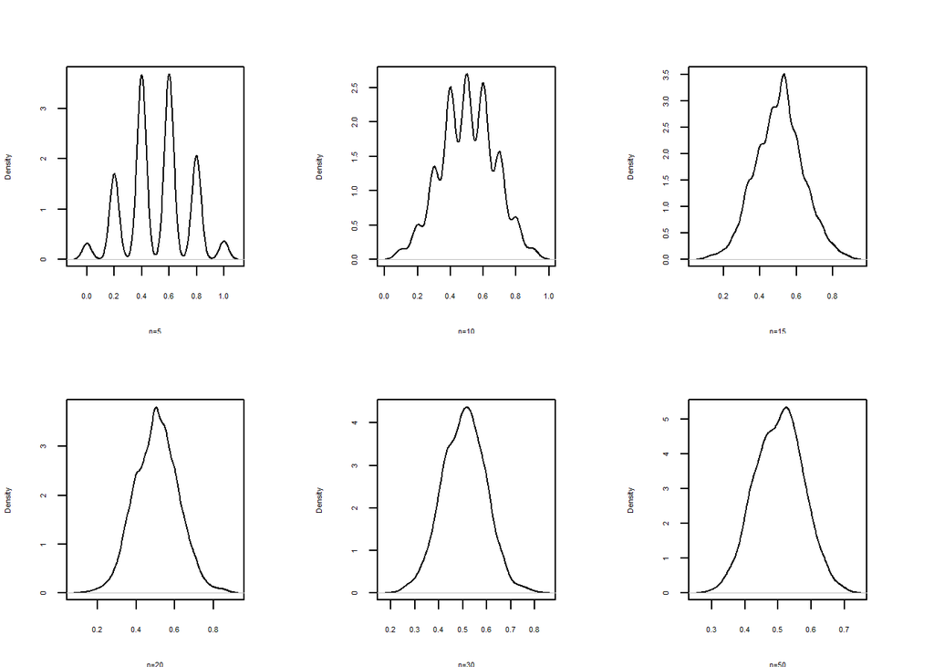

```r
par(cex=0.5, cex.axis=.5, cex.lab=.5, cex.main=.5, cex.sub=.5,  mfrow=c(3,2), mai = c(.5, .5, .5, .5))
# Teorema Central del Límite-----------------------------
# Paso 1
n=500   #  numero de columnas (tamaño máximo de muestra)
m=1000*n
# Caso --------------------------------------------------
# distribución binomial-------------------------------
X = matrix(rbinom(m, size = 1, prob = 0.5), ncol = n)
 #############################
# Paso 2
# generación de muestras--------------------------------

X5=X[ ,1:5]          # n=5
X10=X[ ,1:10]          # n=10
X15=X[ ,1:15]        # n=15
X20=X[ ,1:20]        # n=20
X30=X[ ,1:30]        # n=30
X50=X[ ,1:50]        # n=50
X60=X[ ,1:60]      # n=60
X100=X[ ,1:100]    # n=100
X200=X[ ,1:200]    # n=200
X500=X[ ,1:500]    # n=500
# Paso 3
# generacion de medias-------------------------------------------
Mx5=apply(X5,1,mean)        # medias de muestras de tamaño n=5
Mx10 = apply(X10, 1, mean)  # medias de muestras de tamaño n=10
Mx15 = apply(X15, 1, mean)  # medias de muestras de tamaño n=15
Mx20 = apply(X20, 1, mean)  # medias de muestras de tamaño n=20
Mx30 = apply(X30, 1, mean)  # medias de muestras de tamaño n=30
Mx50 = apply(X50, 1, mean)  # medias de muestras de tamaño n=50
Mx60 = apply(X60, 1, mean)  # medias de muestras de tamaño n=60
Mx100 = apply(X100, 1, mean) # medias de muestras de tamaño n=100
Mx200 = apply(X200, 1, mean) # medias de muestras de tamaño n=200
Mx500 = apply(X500, 1, mean) # medias de muestras de tamaño n=500
# Paso 4
# generación de densidad empírica -------------------------------
d5 = density(Mx5)
d10 = density(Mx10)
d15 = density(Mx15)
d20 = density(Mx20)
d30 = density(Mx30)
d50 = density(Mx50)
d60 = density(Mx60)
d100 = density(Mx100)
d200 = density(Mx200)
d500 = density(Mx500)

# Gráficos de densidad -------------------------------------------
# configuración de las gráficas
par(cex=0.5, cex.axis=.5, cex.lab=.5, cex.main=.5, cex.sub=.5,  mfrow=c(2,3), mai = c(.5, .5, .5, .5))
# histogramas  de comparacion-------------------------------------
plot(d5, main=" ", xlab = "n=5")
plot(d10, main=" ", xlab = "n=10")
plot(d15, main=" ", xlab = "n=15")
plot(d20, main=" ", xlab = "n=20")
plot(d30, main=" ", xlab = "n=30")
plot(d50, main=" ", xlab = "n=50")
```

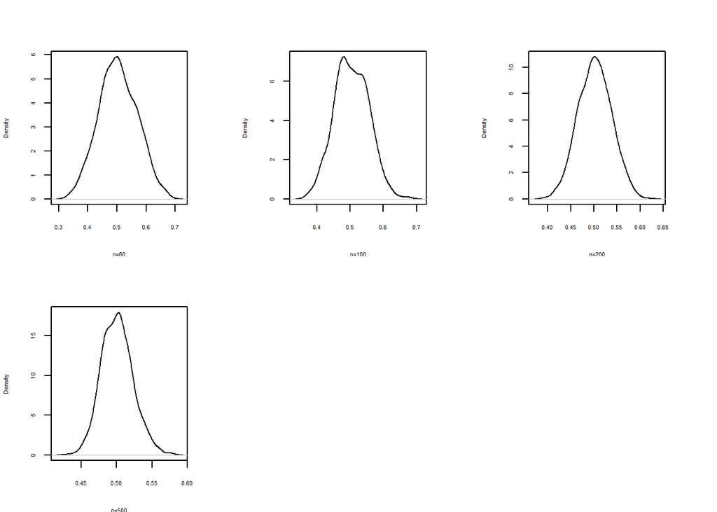

```r
plot(d60, main=" ", xlab = "n=60")
plot(d100, main=" ", xlab = "n=100")
plot(d200, main=" ", xlab = "n=200")
plot(d500, main=" ", xlab = "n=500")
```

comparamos los histogramas y comprobamos cómo tiende a la normalidad la distribución de la media, alrededor de 0.5, el valor del parámetro conforme aumenta la muestra.

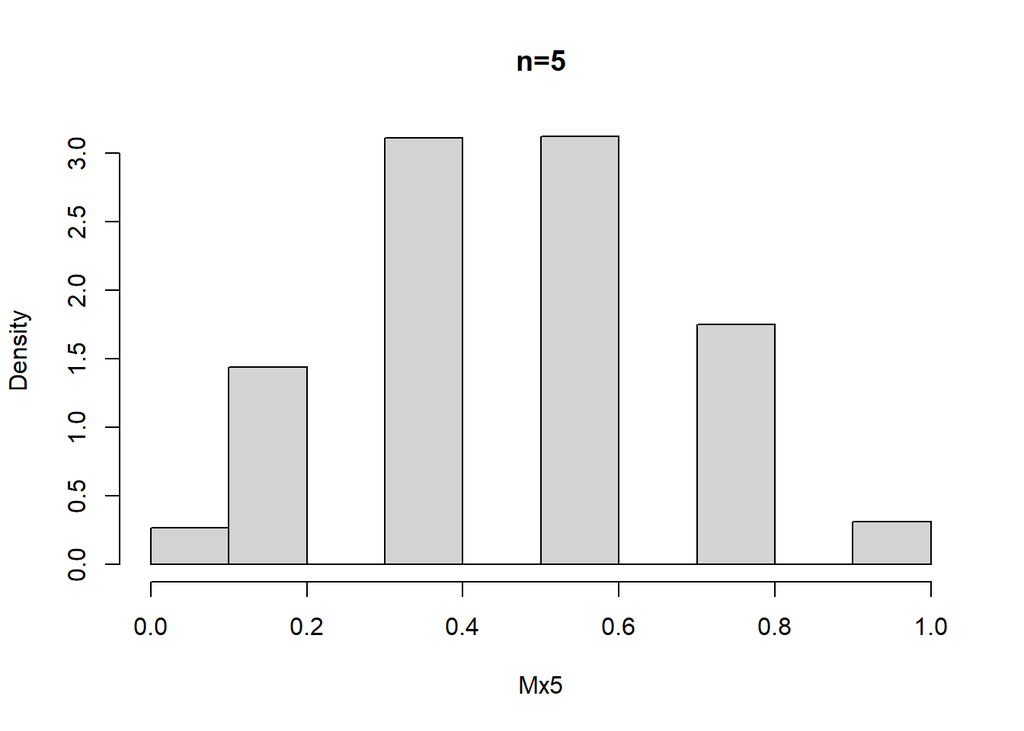

```r
# histogramas  de comparacion-------------------------------------
hist(Mx5, main = "n=5", freq = FALSE)
```

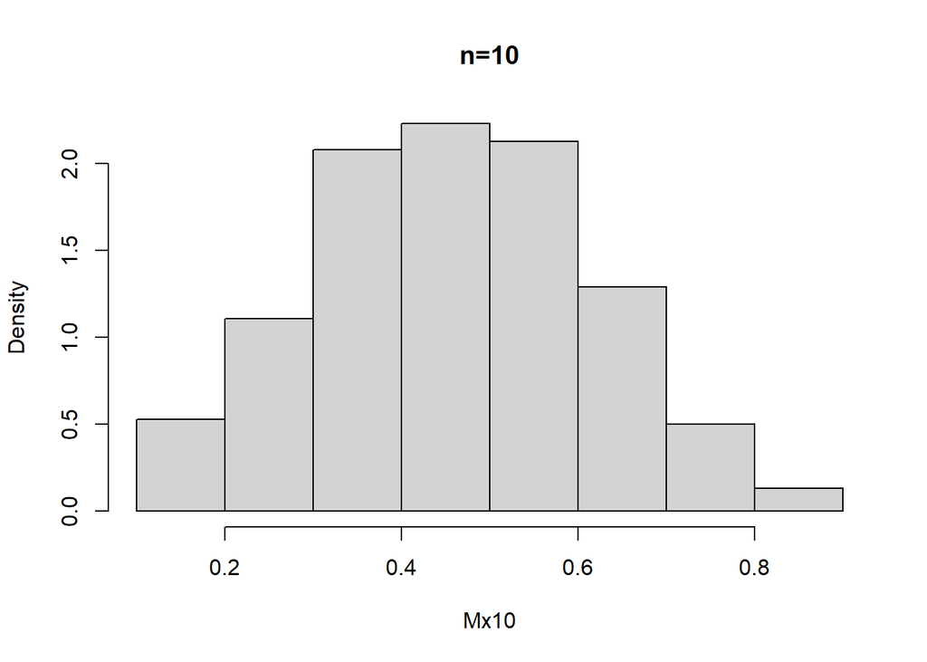

```r
hist(Mx10, main = "n=10", freq = FALSE)
```

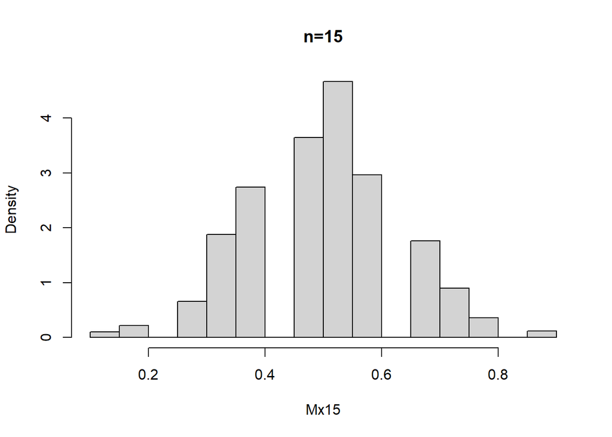

```r
hist(Mx15, main = "n=15", freq = FALSE)
```

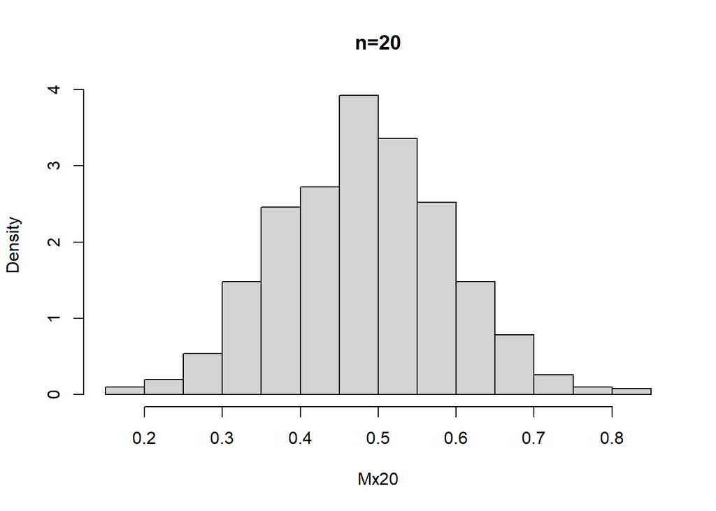

```r
hist(Mx20, main = "n=20", freq = FALSE)
```

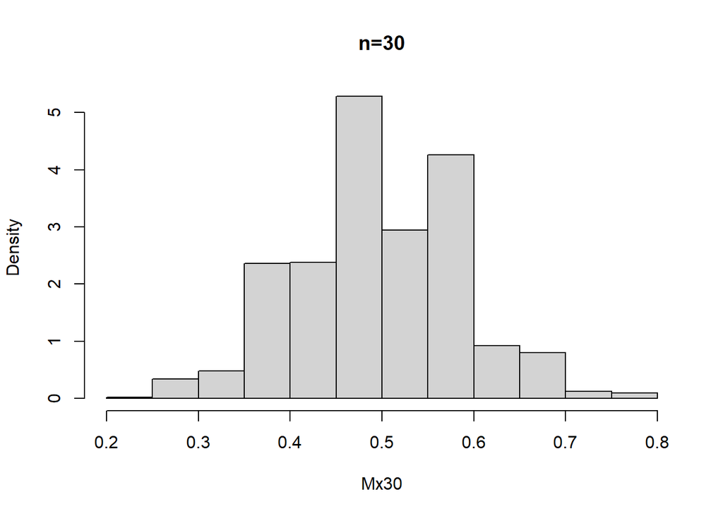

```r
hist(Mx30, main = "n=30", freq = FALSE)
```

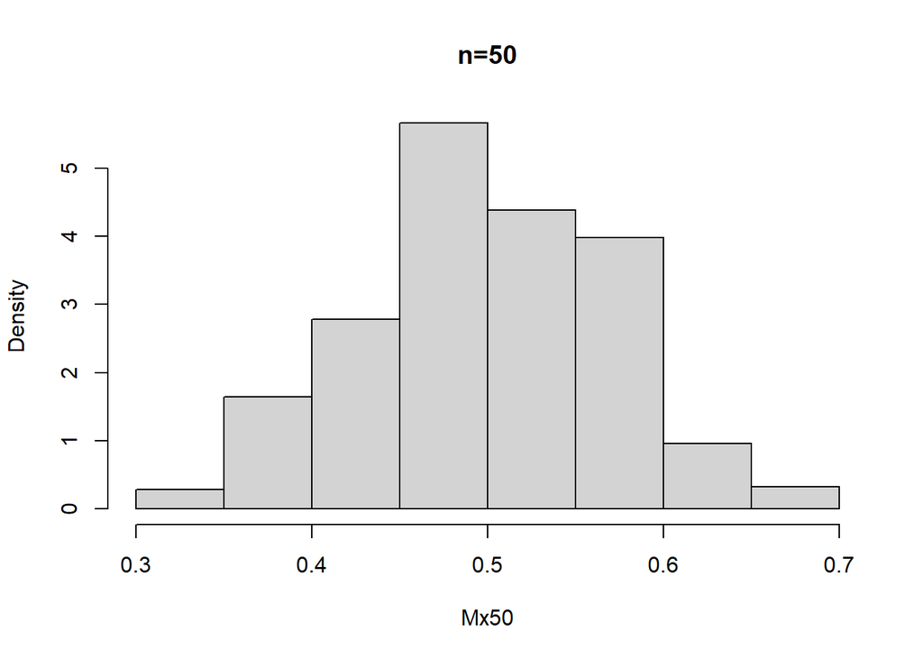

```r
hist(Mx50, main = "n=50", freq = FALSE)
```

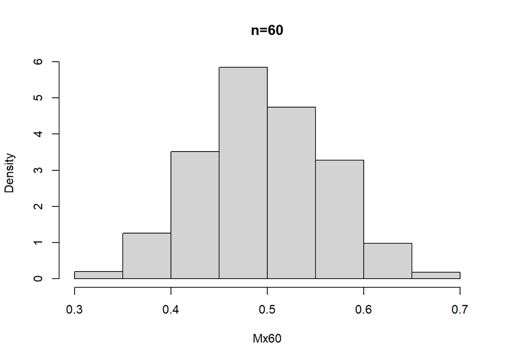

```r
hist(Mx60, main = "n=60", freq = FALSE)
```

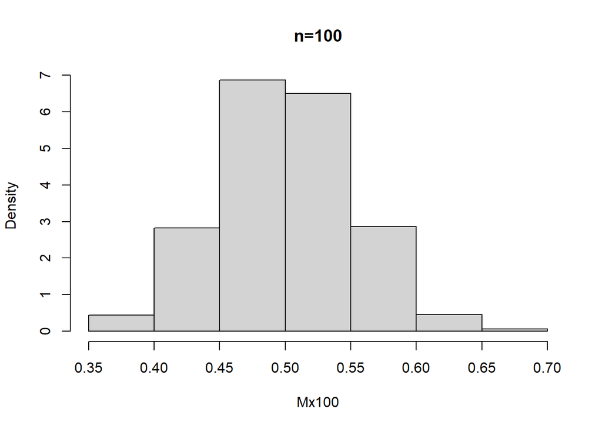

```r
hist(Mx100, main = "n=100", freq = FALSE)
```

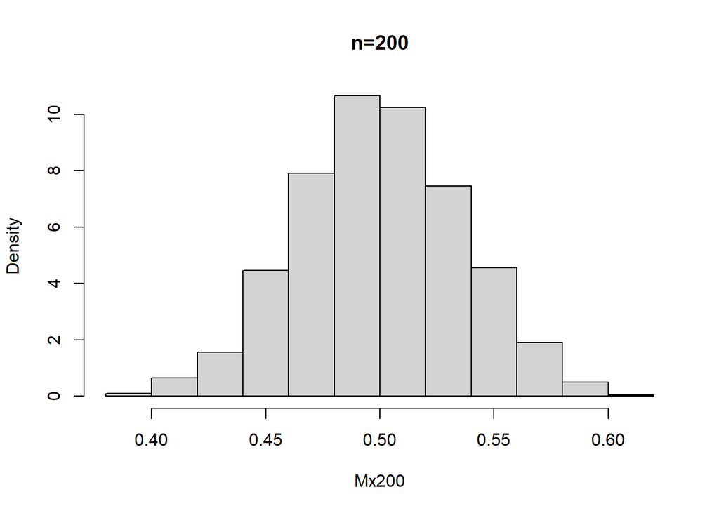

```r
hist(Mx200, main = "n=200", freq = FALSE)
```

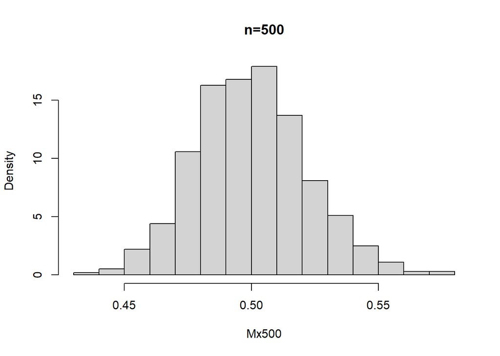

```r
hist(Mx500, main = "n=500", freq = FALSE)
```

Vemos también como reduce la varianza de la media por el tamaño de muestra

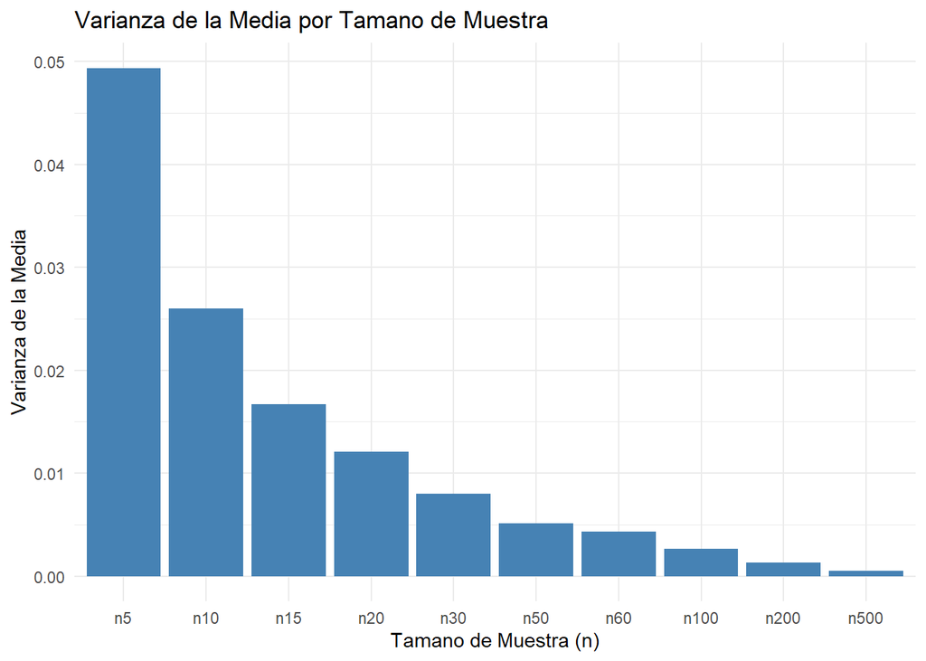

```r
# Calculamos la varianza de las medias para cada conjunto de datos directamente
varianzas <- c(
  n5 = var(Mx5),
  n10 = var(Mx10),
  n15 = var(Mx15),
  n20 = var(Mx20),
  n30 = var(Mx30),
  n50 = var(Mx50),
  n60 = var(Mx60),
  n100 = var(Mx100),
  n200 = var(Mx200),
  n500 = var(Mx500)
)

# Convertimos las varianzas a un data frame para graficar
var_df <- data.frame(n = as.factor(names(varianzas)), Varianza = varianzas)
# Aseguramos que 'n' es un factor y especificamos el orden manualmente
var_df$n <- factor(var_df$n, levels = var_df$n[order(as.numeric(gsub("n=", "", var_df$n)))])

# Ahora, creamos la gráfica con ggplot2
library(ggplot2)
ggplot(var_df, aes(x = n, y = Varianza)) +
  geom_col(fill = "steelblue") +
  theme_minimal() +
  labs(title = "Varianza de la Media por Tamano de Muestra",
       x = "Tamano de Muestra (n)",
       y = "Varianza de la Media")
```

Se incluye además un análisis de variabilidad para revisar la dispersión de los datos y se identifica, como se mostró previamente que se reduce la variabilidad de los datos conforme se incrementa la muestra y se corrigen los sesgos que ocurren en valores inferiores.

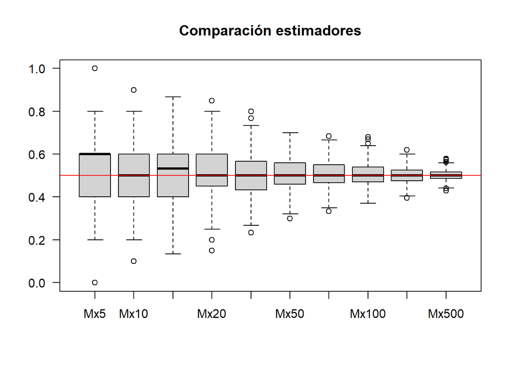

```r
mxmatriz=data.frame(Mx5, Mx10, Mx15, Mx20, Mx30, Mx50, Mx60, Mx100, Mx200, Mx500 )

boxplot(mxmatriz, las=1, main="Comparación estimadores")  # gráfico de comparación
abline(h=0.5,  col="red")                                       # línea indicando el parámetro b=20
```

*Hipótesis nula (H0):* La muestra proviene de una población normalmente distribuida. Esto significa que no hay evidencia de que la distribución de los datos se desvíe de una distribución normal.

*Hipótesis alternativa (Ha):* La muestra no proviene de una población normalmente distribuida. Indica que hay evidencia de que la distribución de los datos se desvía de la normalidad.

```r
# n=5
shapiro.test(Mx5)
```

```
##
##  Shapiro-Wilk normality test
##
## data:  Mx5
## W = 0.92814, p-value < 2.2e-16
```

```r
# n=10
shapiro.test(Mx10)
```

```
##
##  Shapiro-Wilk normality test
##
## data:  Mx10
## W = 0.9652, p-value = 1.015e-14
```

```r
# n=15
shapiro.test(Mx15)
```

```
##
##  Shapiro-Wilk normality test
##
## data:  Mx15
## W = 0.97604, p-value = 8.835e-12
```

```r
# n=20
shapiro.test(Mx20)
```

```
##
##  Shapiro-Wilk normality test
##
## data:  Mx20
## W = 0.98156, p-value = 6.141e-10
```

```r
# n=30
shapiro.test(Mx30)
```

```
##
##  Shapiro-Wilk normality test
##
## data:  Mx30
## W = 0.98739, p-value = 1.412e-07
```

```r
# n=50
shapiro.test(Mx50)
```

```
##
##  Shapiro-Wilk normality test
##
## data:  Mx50
## W = 0.99144, p-value = 1.489e-05
```

```r
# n=60
shapiro.test(Mx60)
```

```
##
##  Shapiro-Wilk normality test
##
## data:  Mx60
## W = 0.99144, p-value = 1.495e-05
```

```r
# n=100
shapiro.test(Mx100)
```

```
##
##  Shapiro-Wilk normality test
##
## data:  Mx100
## W = 0.99397, p-value = 0.0004666
```

```r
# n=200
shapiro.test(Mx200)
```

```
##
##  Shapiro-Wilk normality test
##
## data:  Mx200
## W = 0.99752, p-value = 0.1333
```

```r
# n=500
shapiro.test(Mx500)
```

```
##
##  Shapiro-Wilk normality test
##
## data:  Mx500
## W = 0.99525, p-value = 0.003304
```

Finalizamos generando el gráfico QQ para las proporciones de plantas enfermas

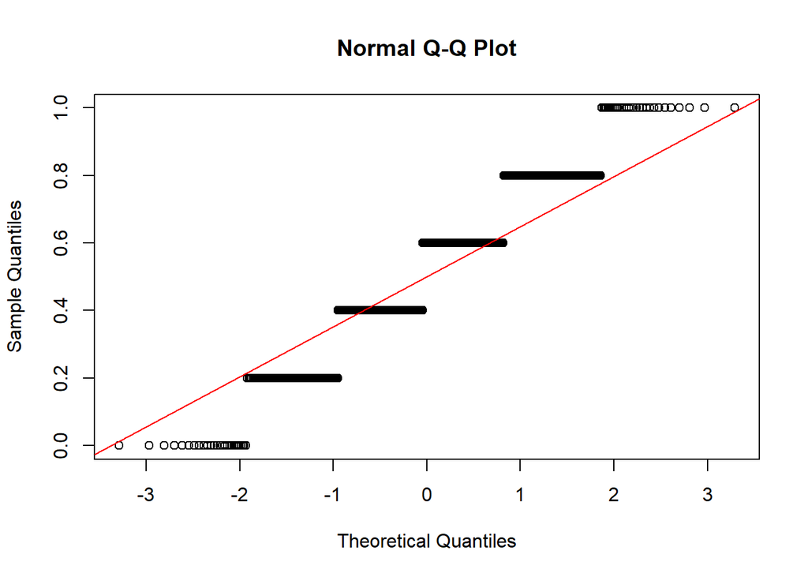

```r
# n=5
qqnorm(Mx5)
qqline(Mx5, col="red")
```

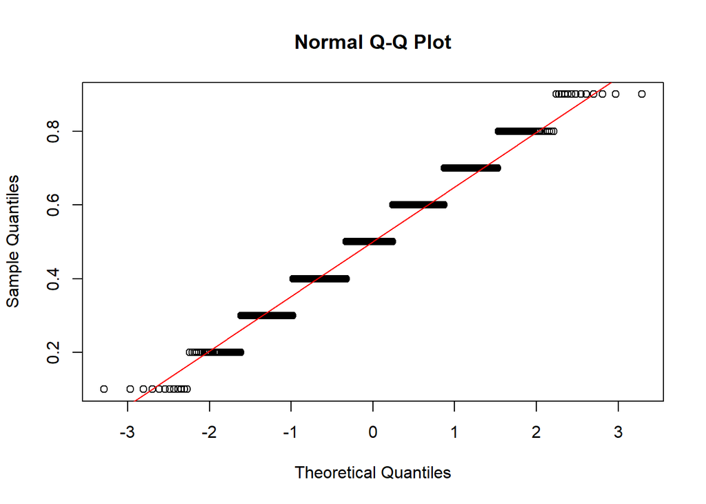

```r
# n=10
qqnorm(Mx10)
qqline(Mx10, col="red")
```

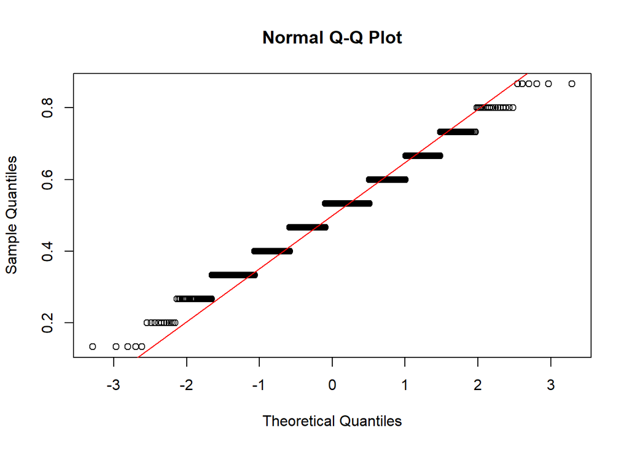

```r
# n=15
qqnorm(Mx15)
qqline(Mx15, col="red")
```

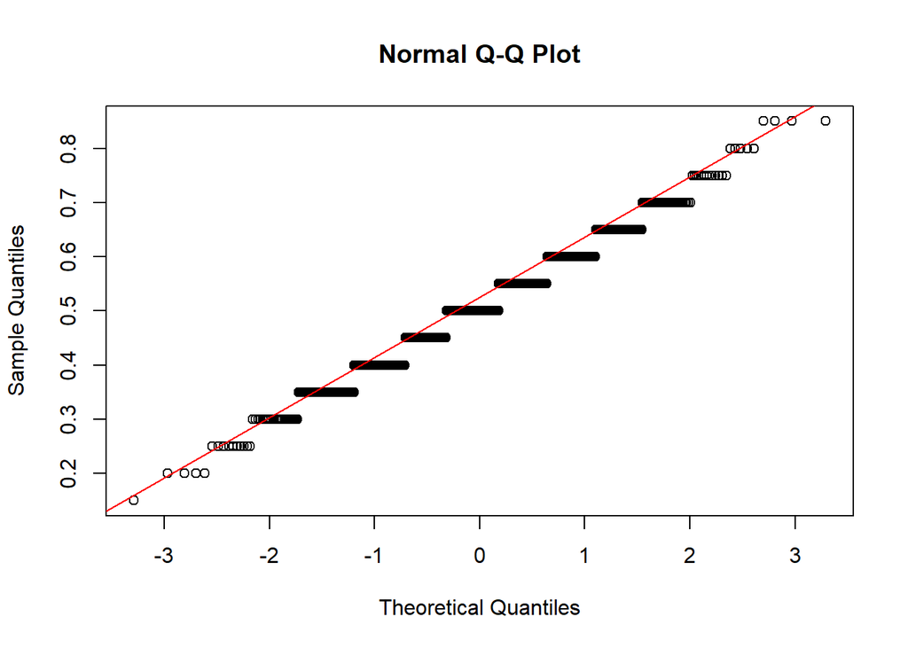

```r
# n=20
qqnorm(Mx20)
qqline(Mx20, col="red")
```

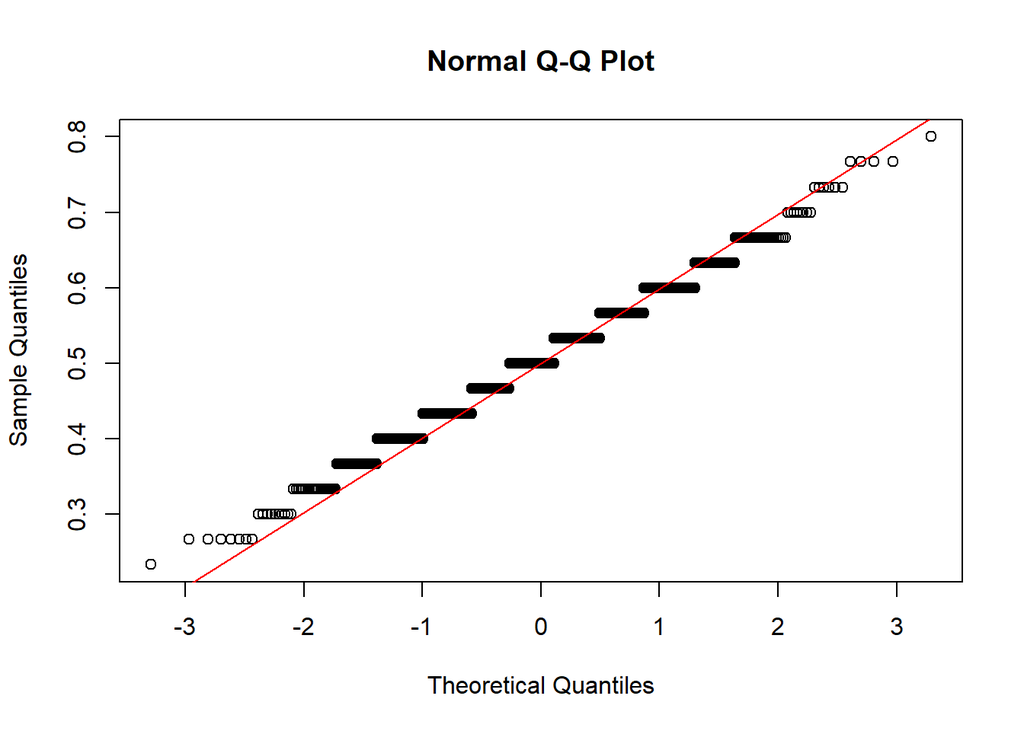

```r
# n=30
qqnorm(Mx30)
qqline(Mx30, col="red")
```

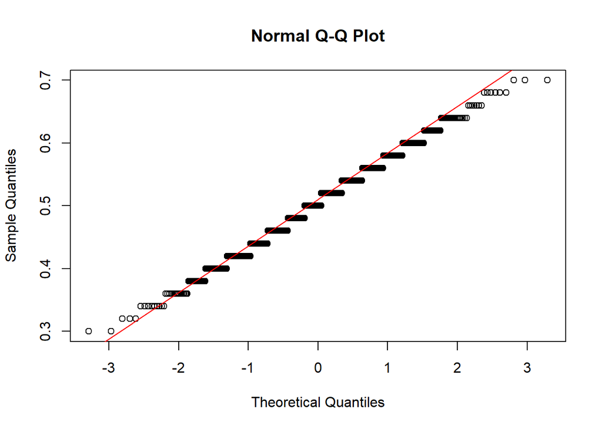

```r
# n=50
qqnorm(Mx50)
qqline(Mx50, col="red")
```

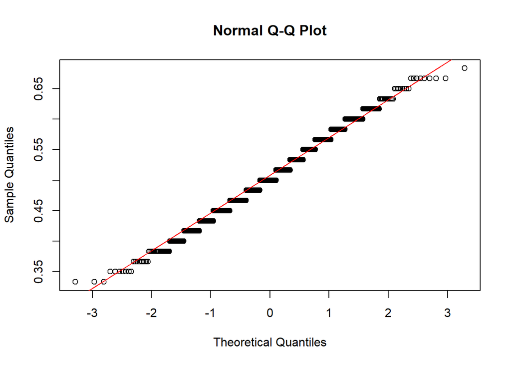

```r
# n=60
qqnorm(Mx60)
qqline(Mx60, col="red")
```

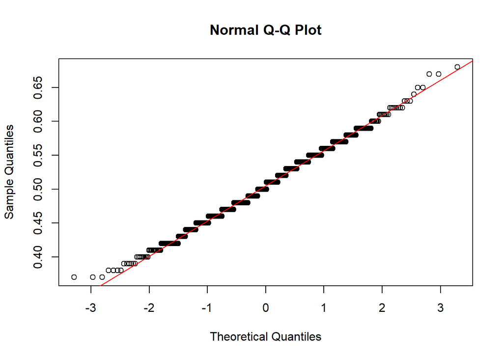

```r
# n=100
qqnorm(Mx100)
qqline(Mx100, col="red")
```

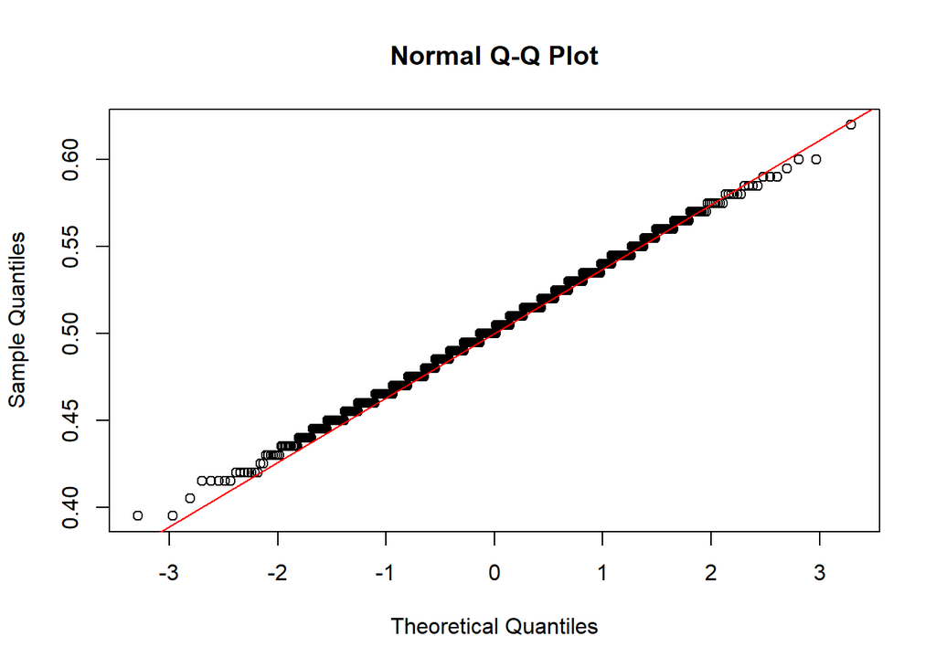

```r
# n=200
qqnorm(Mx200)
qqline(Mx200, col="red")
```

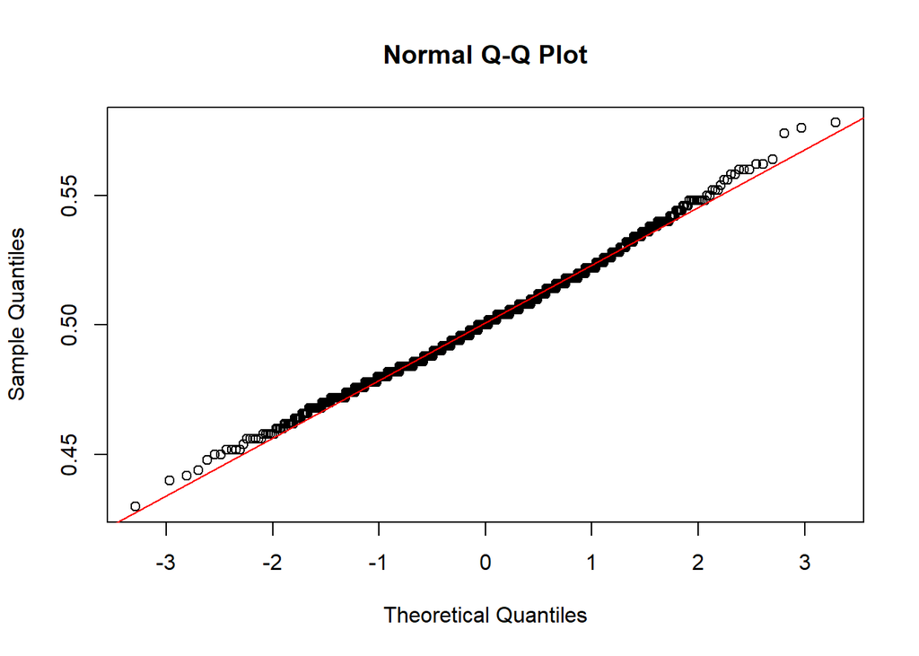

```r
# n=500
qqnorm(Mx500)
qqline(Mx500, col="red")
```

# 5 Punto E

Repita toda la simulación (puntos a – d), pero ahora para lotes con 10% de plantas enfermas y de nuevo para lotes con un 90% de plantas enfermas. Concluya sobre los resultados del ejercicio..

Respuesta:

## 5.1 10 % plantas enfermas

Lotes con 10% de plantas enfermas.

Revisamos las distribuciones de la media (el estimador) para cada número de n y vemos cómo se aproxima a la distribución normal su media, en este caso con el 10% de las plantas enfermas.

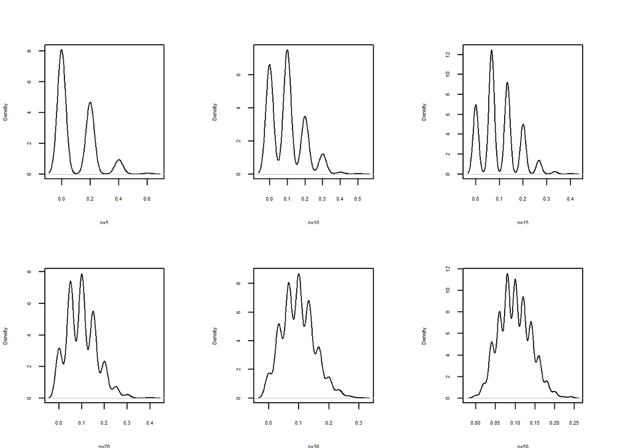

```r
par(cex=0.5, cex.axis=.5, cex.lab=.5, cex.main=.5, cex.sub=.5,  mfrow=c(3,2), mai = c(.5, .5, .5, .5))
# Teorema Central del Límite-----------------------------
# Paso 1
n=500   #  numero de columnas (tamaño máximo de muestra)
m=1000*n
# Caso --------------------------------------------------
# distribución binomial-------------------------------
X = matrix(rbinom(m, size = 1, prob = 0.1), ncol = n)
 #############################
# Paso 2
# generación de muestras--------------------------------

X5=X[ ,1:5]          # n=5
X10=X[ ,1:10]          # n=10
X15=X[ ,1:15]        # n=15
X20=X[ ,1:20]        # n=20
X30=X[ ,1:30]        # n=30
X50=X[ ,1:50]        # n=50
X60=X[ ,1:60]      # n=60
X100=X[ ,1:100]    # n=100
X200=X[ ,1:200]    # n=200
X500=X[ ,1:500]    # n=500
# Paso 3
# generacion de medias-------------------------------------------
Mx5=apply(X5,1,mean)        # medias de muestras de tamaño n=5
Mx10 = apply(X10, 1, mean)  # medias de muestras de tamaño n=10
Mx15 = apply(X15, 1, mean)  # medias de muestras de tamaño n=15
Mx20 = apply(X20, 1, mean)  # medias de muestras de tamaño n=20
Mx30 = apply(X30, 1, mean)  # medias de muestras de tamaño n=30
Mx50 = apply(X50, 1, mean)  # medias de muestras de tamaño n=50
Mx60 = apply(X60, 1, mean)  # medias de muestras de tamaño n=60
Mx100 = apply(X100, 1, mean) # medias de muestras de tamaño n=100
Mx200 = apply(X200, 1, mean) # medias de muestras de tamaño n=200
Mx500 = apply(X500, 1, mean) # medias de muestras de tamaño n=500
# Paso 4
# generación de densidad empírica -------------------------------
d5 = density(Mx5)
d10 = density(Mx10)
d15 = density(Mx15)
d20 = density(Mx20)
d30 = density(Mx30)
d50 = density(Mx50)
d60 = density(Mx60)
d100 = density(Mx100)
d200 = density(Mx200)
d500 = density(Mx500)

# Gráficos de densidad -------------------------------------------
# configuración de las gráficas
par(cex=0.5, cex.axis=.5, cex.lab=.5, cex.main=.5, cex.sub=.5,  mfrow=c(2,3), mai = c(.5, .5, .5, .5))
# histogramas  de comparacion-------------------------------------
plot(d5, main=" ", xlab = "n=5")
plot(d10, main=" ", xlab = "n=10")
plot(d15, main=" ", xlab = "n=15")
plot(d20, main=" ", xlab = "n=20")
plot(d30, main=" ", xlab = "n=30")
plot(d50, main=" ", xlab = "n=50")
```

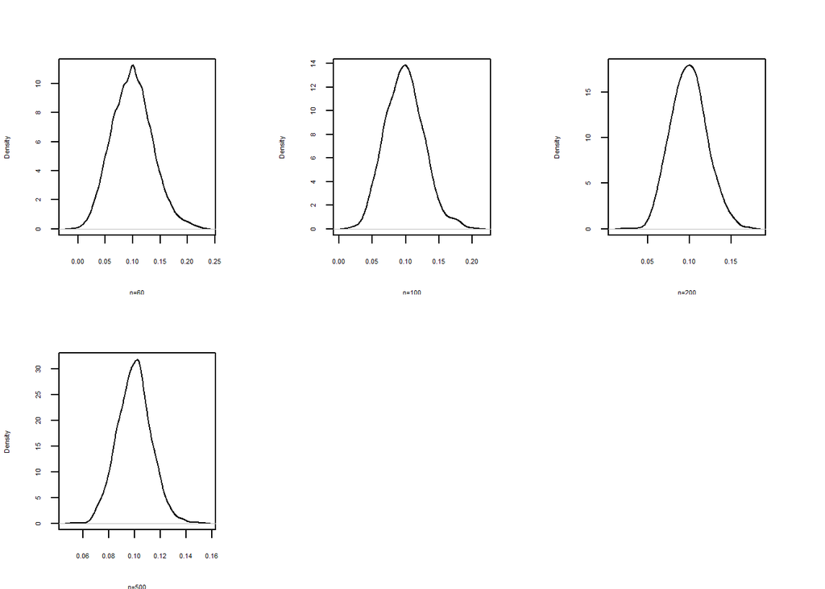

```r
plot(d60, main=" ", xlab = "n=60")
plot(d100, main=" ", xlab = "n=100")
plot(d200, main=" ", xlab = "n=200")
plot(d500, main=" ", xlab = "n=500")
```

comparamos los histogramas y comprobamos cómo tiende a la normalidad la distribución de la media, alrededor de 0.1, el valor del parámetro conforme aumenta la muestra.

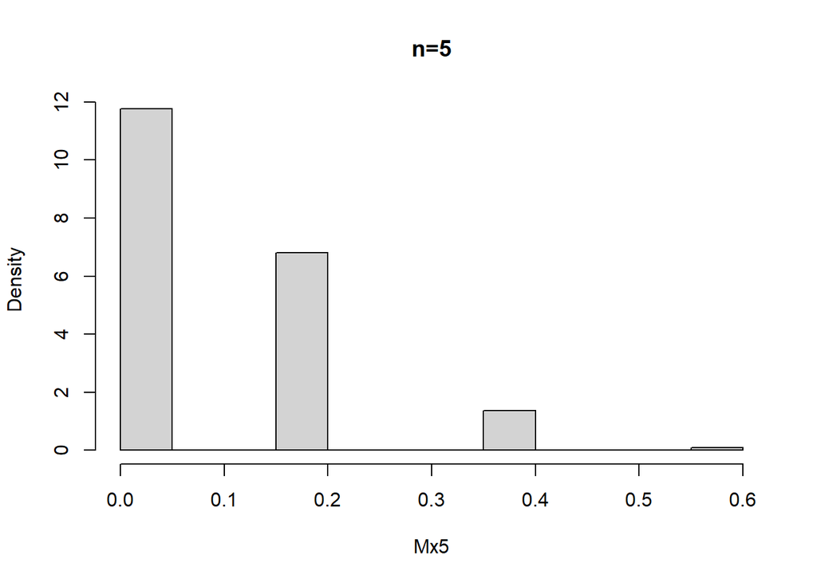

```r
# histogramas  de comparacion-------------------------------------
hist(Mx5, main = "n=5", freq = FALSE)
```